# External Validation of Classical Machine Learning Models for Binary Colorectal Cancer Microbiome Classification

Harshini Chintala

2026-09-04

## 0.1 Notebook roadmap

**Purpose:** This notebook is one reproducible component of the CRC microbiome classification pipeline.

**Execution order** 1. Load the project environment and fixed random seed (`1910`). 2. Load only the validated project artifacts required for this analysis. 3. Perform the analysis exactly as documented below. 4. Generate tables/figures and save machine-readable outputs. 5. Record the session information used for the run.

**Output contract:** generated tables, figures, model objects, audit files, and session information are written under `02 Classical ML/results/`. The notebook itself renders to HTML with a floating table of contents, so the sections can be navigated from the left-hand panel in the knitted document.

**Reproducibility rule:** this repository preserves the validated analysis logic and project-wide seed. Environment restoration is handled by `renv.lock` for R and `requirements.txt` for Python. The notebooks do not silently install unpinned packages during knitting.

### 0.1.1 Reproducibility constants

- Project seed: **1910**
- Discovery cohort: **ZellerG_2014**
- Primary task: **Healthy vs CRC; adenoma excluded**
- Frozen discovery split: **92 training / 22 held-out test samples**
- Primary feature panel: **20 Boruta-selected features**
- External cohorts: **FengQ_2015** and **VogtmannE_2016**

# 1 Introduction

The four primary classical models in this project (Binomial Logistic Regression, Random Forest, SVM, and XGBoost) were trained and evaluated entirely within the Zeller et al. (`ZellerG_2014`) discovery cohort, using a stratified 80:20 train/test split and repeated 10-fold x 5-repeat cross-validation. Cross-validation and a held-out test split both resample the *same* underlying cohort, so a model can look robust internally while still encoding population-, protocol-, or batch-specific structure that does not transfer to an unrelated cohort. Internal repeated CV is therefore necessary but not sufficient evidence of generalizability.

This notebook adds one additional, independent evidence layer: it takes the four **already-fitted, already-frozen** classical models exactly as saved by the primary pipeline and applies them, without any retraining, retuning, refitting, or re-selection of features, to a genuinely independent CRC microbiome cohort accessed through `curatedMetagenomicData`.

**Discovery cohort:** Zeller et al. 2014 (`ZellerG_2014`), Healthy vs CRC, adenoma excluded, 92 train / 22 test samples, 20 Boruta-selected microbial features, seed `1910`.

**What is being validated:** the four frozen classical models’ predictions on unseen, out-of-cohort samples, using the discovery cohort’s fitted scaler, fitted Boruta-selected feature list, and fitted model objects exactly as they exist on disk.

**What is deliberately NOT being retrained:** Boruta is not re-run, the scaler is not refit, no hyperparameters are retuned, no thresholds are changed, and the QSVC quantum model is out of scope for this notebook (it remains an internal exploratory analysis; see Limitations).

# 2 Objectives

1. Validate the frozen Logistic Regression, Random Forest, SVM, and XGBoost models on an independent cohort.
2. Assess whether the discovery cohort’s 20 Boruta-selected microbial features are available and usable in the external cohort.
3. Compare internal held-out test performance against external validation performance for each model.
4. Identify model-specific shifts in Accuracy, Precision, Sensitivity, Specificity, F1, MCC, and AUC.
5. Quantify the external-validation performance gap per model, without cherry-picking a post-hoc “best” model.

# 3 Project Artifacts Used In This Notebook

Before writing any prediction code, the four existing Rmds (`01_Binomial_Logistic_Regression.Rmd`, `07_Binary_RandomForest_CRC_vs_Healthy.Rmd`, `08_Binary_SVM_CRC_vs_Healthy.Rmd`, `09_Binary_XGBoost_CRC_vs_Healthy.Rmd`) were inspected directly. Each model notebook re-runs Boruta independently (same `seed = 1910`, same 92-sample training partition), so each model has its **own** saved scaler, selected-feature file, and (for three of the four models) its own saved feature-name map, even though all four are expected to converge on the same 20-feature set. This notebook does not assume the four are identical; it loads each model’s own artifacts and audits them independently.

| Model | Model artifact used | Scaler artifact used | Feature artifact used |
| --- | --- | --- | --- |
| Logistic Regression | `models/BinomialLR_Model.rds` | `models/Scaler.rds` | `results/Binary_Selected_20_Features.csv` (no saved name map – this notebook recomputes `make.names()` identically to how `01_Binomial_Logistic_Regression.Rmd` standardized names inline) |
| Random Forest | `models/RandomForestBinary_Model.rds` | `models/Scaler_RandomForest_Binary.rds` | `results/RandomForestBinary_Selected_Features.csv` + `results/RandomForestBinary_FeatureNameMap.csv` |
| SVM | `models/SVMBinary_Model.rds` | `models/Scaler_Binary_SVM.rds` | `results/SVMBinary_Selected_Features.csv` + `results/SVMBinary_FeatureNameMap.csv` |
| XGBoost | `models/XGBoostBinary_Model.model` (native `xgb.load()`) + `models/XGBoostBinary_Model_Params.rds` | `models/Scaler_Binary_XGB.rds` | `results/XGBoostBinary_Selected_Features.csv` + `results/XGBoostBinary_FeatureNameMap.csv` |

None of these paths are placeholders – they are the exact `saveRDS()` / `xgb.save()` / `write.csv()` targets found in the four uploaded Rmds. If any of these files is missing when this notebook runs (e.g. the four Rmds have not all been executed yet in this environment), the artifact-existence check in the next section stops the notebook immediately and names the missing file, rather than producing a false-complete report.

A note on the folder tree: the follow-up output-saving requirement listed the four cohort subfolders two slightly different ways (`predictions/metrics/figures/metadata` in the itemized list, `results/predictions/figures/metadata` in the final diagram). This notebook uses `predictions/`, `metrics/`, `figures/`, `metadata/` per cohort, since that maps cleanly onto the itemized RESULTS / TABLES / FIGURES / REPRODUCIBILITY file list (metrics, AUC, confusion matrices and ROC coordinates all go under `metrics/`; the master and comparison tables are saved there too, plus copied to `results/` at the project root under the exact filenames requested, for quick access without navigating into a cohort folder).

# 4 Package Check

```r
cran_packages  <- c("caret", "tidyverse", "pROC", "MLmetrics", "Boruta",
                     "yardstick", "randomForest", "kernlab", "xgboost",
                     "stringr", "dplyr", "ggplot2")
bioc_packages  <- c("curatedMetagenomicData", "TreeSummarizedExperiment")

check_and_install <- function(cran_pkgs, bioc_pkgs) {
  all_packages <- c(cran_pkgs, bioc_pkgs)
  missing <- all_packages[
    !vapply(all_packages, requireNamespace, logical(1), quietly = TRUE)
  ]
  if (length(missing)) {
    stop(
      "Missing package(s). Restore the validated environment with ",
      "renv::restore() before knitting: ",
      paste(missing, collapse = ", ")
    )
  }
}

check_and_install(cran_packages, bioc_packages)

all_packages <- c(cran_packages, bioc_packages)
invisible(lapply(all_packages, library, character.only = TRUE))

package_versions <- data.frame(
  Package = all_packages,
  Version = vapply(all_packages, function(p) as.character(packageVersion(p)), character(1)),
  row.names = NULL
)

write.csv(
  package_versions,
  file.path(reports_dir, "ExternalValidation_PackageVersions.csv"),
  row.names = FALSE
)

package_versions
```

| Package | Version |
| --- | --- |
| caret | 7.0.1 |
| tidyverse | 2.0.0 |
| pROC | 1.19.1 |
| MLmetrics | 1.1.3 |
| Boruta | 10.0.0 |
| yardstick | 1.4.0 |
| randomForest | 4.7.1.2 |
| kernlab | 0.9.33 |
| xgboost | 3.2.1.1 |
| stringr | 1.6.0 |

[output cut: 4 more lines]

# 5 Reproducibility

```r
set.seed(1910)
```

# 6 Load Frozen Model Artifacts

```r
# ==========================================================
# One entry per frozen classical model, using the exact
# artifact paths identified above. internal_metrics reproduces
# the already-independently-verified held-out test performance
# from the primary pipeline; it is not regenerated here.
# ==========================================================

model_configs <- list(
  LogisticRegression = list(
    label           = "LogisticRegression",
    display         = "Binomial Logistic Regression",
    model_path      = file.path(models_dir, "BinomialLR_Model.rds"),
    scaler_path     = file.path(models_dir, "Scaler.rds"),
    features_path   = file.path(results_dir, "Binary_Selected_20_Features.csv"),
    featuremap_path = NA_character_,
    model_type      = "caret",
    internal_metrics = data.frame(Accuracy = 0.818, Precision = 0.800, Sensitivity = 0.800,
                                   Specificity = 0.833, F1 = 0.800, MCC = 0.633, AUC = 0.850)
  ),

  RandomForest = list(
    label           = "RandomForest",
    display         = "Random Forest",
    model_path      = file.path(models_dir, "RandomForestBinary_Model.rds"),
    scaler_path     = file.path(models_dir, "Scaler_RandomForest_Binary.rds"),
    features_path   = file.path(results_dir, "RandomForestBinary_Selected_Features.csv"),
    featuremap_path = file.path(results_dir, "RandomForestBinary_FeatureNameMap.csv"),
    model_type      = "caret",
    internal_metrics = data.frame(Accuracy = 0.818, Precision = 0.800, Sensitivity = 0.800,
                                   Specificity = 0.833, F1 = 0.800, MCC = 0.633, AUC = 0.817)
  ),
  SVM = list(
    label           = "SVM",
    display         = "Support Vector Machine (RBF)",
    model_path      = file.path(models_dir, "SVMBinary_Model.rds"),
    scaler_path     = file.path(models_dir, "Scaler_Binary_SVM.rds"),
    features_path   = file.path(results_dir, "SVMBinary_Selected_Features.csv"),
    featuremap_path = file.path(results_dir, "SVMBinary_FeatureNameMap.csv"),
    model_type      = "caret",
    internal_metrics = data.frame(Accuracy = 0.727, Precision = 0.750, Sensitivity = 0.600,
                                   Specificity = 0.833, F1 = 0.667, MCC = 0.449, AUC = 0.717)
  ),
  XGBoost = list(
    label           = "XGBoost",
    display         = "XGBoost",
    model_path      = file.path(models_dir, "XGBoostBinary_Model.model"),
    params_path     = file.path(models_dir, "XGBoostBinary_Model_Params.rds"),
    scaler_path     = file.path(models_dir, "Scaler_Binary_XGB.rds"),
    features_path   = file.path(results_dir, "XGBoostBinary_Selected_Features.csv"),
    featuremap_path = file.path(results_dir, "XGBoostBinary_FeatureNameMap.csv"),
    model_type      = "xgboost",
    internal_metrics = data.frame(Accuracy = 0.636, Precision = 0.750, Sensitivity = 0.300,
                                   Specificity = 0.917, F1 = 0.429, MCC = 0.280, AUC = 0.750)
  )
)
# ==========================================================
# Diagnostic: frozen model artifact paths used during Knit
# ==========================================================

cat(
  "\nFrozen model artifact paths used during Knit:\n\n"
)
```

```
##
## Frozen model artifact paths used during Knit:
```

```r
for (cfg_name in names(model_configs)) {

  cat(
    cfg_name,
    "\n",
    "Model   : ", model_configs[[cfg_name]]$model_path, "\n",
    "Scaler  : ", model_configs[[cfg_name]]$scaler_path, "\n",
    "Features: ", model_configs[[cfg_name]]$features_path, "\n\n",
    sep = ""
  )
}
## LogisticRegression
## Model   : C:/CRC/CRC_Quantum_Microbiome_Githb/CRC_Quantum_Microbiome_GitHub_RMD/02 Classical ML/models/BinomialLR_Model.rds
## Scaler  : C:/CRC/CRC_Quantum_Microbiome_Githb/CRC_Quantum_Microbiome_GitHub_RMD/02 Classical ML/models/Scaler.rds
## Features: C:/CRC/CRC_Quantum_Microbiome_Githb/CRC_Quantum_Microbiome_GitHub_RMD/02 Classical ML/results/Binary_Selected_20_Features.csv
##
## RandomForest
## Model   : C:/CRC/CRC_Quantum_Microbiome_Githb/CRC_Quantum_Microbiome_GitHub_RMD/02 Classical ML/models/RandomForestBinary_Model.rds
## Scaler  : C:/CRC/CRC_Quantum_Microbiome_Githb/CRC_Quantum_Microbiome_GitHub_RMD/02 Classical ML/models/Scaler_RandomForest_Binary.rds
## Features: C:/CRC/CRC_Quantum_Microbiome_Githb/CRC_Quantum_Microbiome_GitHub_RMD/02 Classical ML/results/RandomForestBinary_Selected_Features.csv
##
## SVM
## Model   : C:/CRC/CRC_Quantum_Microbiome_Githb/CRC_Quantum_Microbiome_GitHub_RMD/02 Classical ML/models/SVMBinary_Model.rds
## Scaler  : C:/CRC/CRC_Quantum_Microbiome_Githb/CRC_Quantum_Microbiome_GitHub_RMD/02 Classical ML/models/Scaler_Binary_SVM.rds
## Features: C:/CRC/CRC_Quantum_Microbiome_Githb/CRC_Quantum_Microbiome_GitHub_RMD/02 Classical ML/results/SVMBinary_Selected_Features.csv
##
## XGBoost
## Model   : C:/CRC/CRC_Quantum_Microbiome_Githb/CRC_Quantum_Microbiome_GitHub_RMD/02 Classical ML/models/XGBoostBinary_Model.model
## Scaler  : C:/CRC/CRC_Quantum_Microbiome_Githb/CRC_Quantum_Microbiome_GitHub_RMD/02 Classical ML/models/Scaler_Binary_XGB.rds
## Features: C:/CRC/CRC_Quantum_Microbiome_Githb/CRC_Quantum_Microbiome_GitHub_RMD/02 Classical ML/results/XGBoostBinary_Selected_Features.csv
```

```r
# ==========================================================
# Artifact existence check -- stop loudly, name the exact
# missing file, rather than proceeding with a false-complete
# notebook.
# ==========================================================

check_artifacts_exist <- function(cfg) {
  required_paths <- c(cfg$model_path, cfg$scaler_path, cfg$features_path)
  if (!is.na(cfg$featuremap_path)) required_paths <- c(required_paths, cfg$featuremap_path)
  if (!is.null(cfg$params_path)) required_paths <- c(required_paths, cfg$params_path)

  missing <- required_paths[!file.exists(required_paths)]
  if (length(missing) > 0) {
    stop(
      "FROZEN MODEL ARTIFACT MISSING for ", cfg$display, ":\n  ",
      paste(missing, collapse = "\n  "),
      "\nExternal validation cannot proceed until 01/07/08/09 Rmds have been run ",
      "and these files exist on disk. Stopping rather than producing a false-complete report."
    )
  }
  invisible(TRUE)
}

invisible(lapply(model_configs, check_artifacts_exist))

cat("All frozen model, scaler, and feature artifacts found for all four models.\n")
## All frozen model, scaler, and feature artifacts found for all four models.
```

Every model artifact, scaler artifact, and feature-list artifact referenced above must exist on disk before this notebook does anything else. This check runs before a single external sample is even loaded, so a missing or not-yet-generated artifact fails the notebook immediately with the exact path that is missing, instead of silently producing partial or fabricated results.

# 7 External Cohort Candidates and Feasibility Gate

```r
# ==========================================================
# First External Cohort and Feasibility Gate
# ==========================================================
# FengQ_2015 is the designated first independent external
# validation cohort in this notebook.
#
# VogtmannE_2016 is evaluated separately in
# 11_External_Validation_VogtmannE_CRC_vs_Healthy.Rmd as the
# second independent external validation cohort.
#
# The two cohorts are reported separately and are not pooled
# into a single primary external-validation metric.
# ==========================================================

COHORT_CANDIDATES <- "FengQ_2015"
MIN_SAMPLES_PER_CLASS <- 15   # judgment call: floor for a class to be usable for external metrics
REQUIRE_ALL_20_FEATURES <- TRUE  # per-model; strict by design (see Section 7 of the master prompt)
```

```r
# ==========================================================
# Load one external cohort via curatedMetagenomicData, using
# the identical retrieval convention as ZellerG_2014 in
# 01_Binomial_Logistic_Regression.Rmd (same function call
# shape, same dryrun = FALSE, same [[1]] extraction, same
# assay()/colData() access pattern).
# ==========================================================

load_external_cohort <- function(cohort_name) {
  cmd_obj <- curatedMetagenomicData(
    paste0(cohort_name, ".relative_abundance"),
    dryrun = FALSE
  )[[1]]

  abundance <- assay(cmd_obj)
  X <- as.data.frame(t(abundance))
  y <- colData(cmd_obj)$study_condition
  sample_ids <- colnames(cmd_obj)

  list(X = X, y = y, sample_ids = sample_ids, meta = colData(cmd_obj))
}
```

```r
# ==========================================================
# Feasibility gate. Must PASS before any prediction is made.
# Checks, per Section 12 of the master prompt:
#   - both classes exist
#   - sample count is non-zero and >= MIN_SAMPLES_PER_CLASS per class
#   - the expected 20 features are available (per-model audit)
#   - no duplicate sample IDs
#   - no NA problems in the resulting model matrix
# Fails loudly and cleanly rather than silently continuing with
# an incomplete feature set.
# ==========================================================

run_feasibility_check <- function(cohort_name) {

  cat("\n----- Feasibility check:", cohort_name, "-----\n")

  loaded <- tryCatch(
    load_external_cohort(cohort_name),
    error = function(e) {
      cat("FAILED to load", cohort_name, "via curatedMetagenomicData:", conditionMessage(e), "\n")
      return(NULL)
    }
  )
  if (is.null(loaded)) {
    return(list(cohort = cohort_name, pass = FALSE, reason = "Load failure", data = NULL))
  }

  binary_df <- loaded$X
  binary_df$disease    <- dplyr::case_match(loaded$y, "control" ~ "healthy", .default = loaded$y)
  binary_df$SampleID   <- loaded$sample_ids

  binary_df <- binary_df[binary_df$disease %in% c("healthy", "CRC"), , drop = FALSE]
  binary_df$disease <- factor(binary_df$disease, levels = c("healthy", "CRC"))

  n_healthy <- sum(binary_df$disease == "healthy")
  n_crc     <- sum(binary_df$disease == "CRC")

  reasons <- c()

  if (n_healthy == 0 || n_crc == 0) {
    reasons <- c(reasons, "One class is entirely absent after excluding adenoma.")
  }
  if (n_healthy < MIN_SAMPLES_PER_CLASS || n_crc < MIN_SAMPLES_PER_CLASS) {
    reasons <- c(reasons, sprintf(
      "Fewer than %d samples in at least one class (Healthy=%d, CRC=%d).",
      MIN_SAMPLES_PER_CLASS, n_healthy, n_crc
    ))
  }
  if (anyDuplicated(binary_df$SampleID) > 0) {
    reasons <- c(reasons, "Duplicate sample IDs detected.")
  }

  # Per-model feature-overlap audit
  feature_audit_list <- lapply(model_configs, function(cfg) {
    sel <- read.csv(cfg$features_path, stringsAsFactors = FALSE)$Feature
    found <- sel %in% colnames(binary_df)
    data.frame(Model = cfg$label, Feature = sel, Found_In_External = found,
               stringsAsFactors = FALSE)
  })
  feature_audit <- do.call(rbind, feature_audit_list)

  models_with_gaps <- unique(feature_audit$Model[!feature_audit$Found_In_External])
  if (REQUIRE_ALL_20_FEATURES && length(models_with_gaps) > 0) {
    reasons <- c(reasons, paste0(
      "Incomplete feature overlap for: ", paste(models_with_gaps, collapse = ", "),
      ". See feature-alignment audit for exact missing taxa."
    ))
  }

  pass <- length(reasons) == 0

  cat("Healthy samples:", n_healthy, " | CRC samples:", n_crc, "\n")
  cat("Feature overlap complete for all 4 models:", length(models_with_gaps) == 0, "\n")
  cat("Feasibility result:", if (pass) "PASS" else "FAIL", "\n")
  if (!pass) cat("Reasons:\n - ", paste(reasons, collapse = "\n - "), "\n")

  list(
    cohort = cohort_name,
    pass = pass,
    reason = if (pass) "OK" else paste(reasons, collapse = " | "),
    data = binary_df,
    meta = loaded$meta,
    n_healthy = n_healthy,
    n_crc = n_crc,
    feature_audit = feature_audit
  )
}
```

```r
feasibility_results <- list()
selected_cohort <- NULL

for (cand in COHORT_CANDIDATES) {
  res <- run_feasibility_check(cand)
  feasibility_results[[cand]] <- res
  if (res$pass) {
    selected_cohort <- res
    break
  }
}
```

```
##
## ----- Feasibility check: FengQ_2015 -----
## Healthy samples: 61  | CRC samples: 46
## Feature overlap complete for all 4 models: TRUE
## Feasibility result: PASS
```

```r
if (is.null(selected_cohort)) {
  stop(
    "No candidate external cohort (", paste(COHORT_CANDIDATES, collapse = ", "),
    ") passed the feasibility gate. Stopping cleanly rather than substituting an ",
    "unvetted cohort or an incomplete feature set. See feasibility_results for details ",
    "on why each candidate failed."
  )
}

cat("\nSelected external cohort:", selected_cohort$cohort, "\n")
```

```
##
## Selected external cohort: FengQ_2015
```

`FengQ_2015` is the primary candidate because it is a published, independently recruited CRC/healthy stool metagenomic cohort (Feng et al. 2015) that is genuinely distinct from Zeller et al.’s cohort – different recruitment, different country, different sequencing run – and is retrieved through the same `curatedMetagenomicData` package and `relative_abundance` data type as the discovery cohort, which gives the best chance of taxonomic naming compatibility with the discovery pipeline’s `g__/s__` feature strings. Following successful validation using the FengQ cohort, a second independent external cohort, VogtmannE, was also evaluated to further assess the reproducibility and cross-cohort generalizability of the frozen machine learning models.

```r
# ==========================================================
# Chunk 9
# Per-model NA audit
# ==========================================================

na_audit <- lapply(model_configs, function(cfg) {

  sel <- read.csv(
    cfg$features_path,
    stringsAsFactors = FALSE
  )

  # Extract feature names
  selected_features <- sel[[1]]

  # Check for missing values in the selected external-cohort features
  anyNA(
    selected_cohort$data[, selected_features, drop = FALSE]
  )
})

na_audit
```

```
## $LogisticRegression
## [1] FALSE
##
## $RandomForest
## [1] FALSE
##
## $SVM
## [1] FALSE
##
## $XGBoost
## [1] FALSE
```

```r
make_cohort_dirs <- function(cohort_name) {

  cohort_root <- file.path(results_dir, cohort_name)

  dirs <- c(
    predictions = file.path(cohort_root, "predictions"),
    metrics     = file.path(cohort_root, "metrics"),
    figures     = file.path(cohort_root, "figures"),
    metadata    = file.path(cohort_root, "metadata")
  )

  for (d in dirs) {
    dir.create(
      d,
      recursive = TRUE,
      showWarnings = FALSE
    )
  }

  dirs
}
cohort_dirs <- make_cohort_dirs(selected_cohort$cohort)
```

# 8 External Cohort Metadata

```r
# ==========================================================
# Record dataset name, sample counts, and available metadata
# fields, exactly as required by Section 11 of the master
# prompt.
# ==========================================================

cohort_summary <- data.frame(
  Dataset = selected_cohort$cohort,
  N_Total = nrow(selected_cohort$data),
  N_Healthy = selected_cohort$n_healthy,
  N_CRC = selected_cohort$n_crc,
  Available_Metadata_Fields = paste(colnames(selected_cohort$meta), collapse = "; ")
)

write.csv(
  cohort_summary,
  file.path(cohort_dirs["metadata"], paste0("External_", selected_cohort$cohort, "_SampleSummary.csv")),
  row.names = FALSE
)

write.csv(
  selected_cohort$feature_audit,
  file.path(cohort_dirs["metadata"], "External_Validation_FeatureAlignmentAudit.csv"),
  row.names = FALSE
)

cohort_summary
```

| Dataset | N_Total | N_Healthy | N_CRC | Available_Metadata_Fields |
| --- | --- | --- | --- | --- |
| FengQ_2015 | 107 | 61 | 46 | study_name; subject_id; body_site; antibiotics_current_use; study_condition; disease; age; age_category; gender; country; non_westernized; sequencing_platform; DNA_extraction_kit; PMID; number_reads; … |

# 9 Apply Frozen Models (Predict Only – No Refitting)

```r
# ==========================================================
# For each model: align external features to the model's own
# selected-feature list (exact names, exact order), apply the
# model's own FROZEN scaler (predict(), never preProcess()
# again), apply the model's own syntactic name map (or
# recompute make.names() identically for Logistic Regression,
# which never saved one), verify the model's expected predictor
# names are all present, then predict. No Boruta, no scaler
# fitting, no hyperparameter search happens anywhere below.
# ==========================================================

apply_frozen_model <- function(cfg, external_data) {

  sel <- read.csv(cfg$features_path, stringsAsFactors = FALSE)$Feature

  stopifnot(all(sel %in% colnames(external_data)))  # re-guarded even though the gate already checked this

  X_ext <- external_data[, sel, drop = FALSE]

  scaler <- readRDS(cfg$scaler_path)
  X_ext_scaled <- predict(scaler, X_ext)   # FROZEN scaler applied, never refit

  if (!is.na(cfg$featuremap_path) && file.exists(cfg$featuremap_path)) {
    fmap <- read.csv(cfg$featuremap_path, stringsAsFactors = FALSE)
    colnames(X_ext_scaled) <- fmap$Syntactic[match(colnames(X_ext_scaled), fmap$Original)]
  } else {
    colnames(X_ext_scaled) <- make.names(colnames(X_ext_scaled), unique = TRUE)
  }

  if (cfg$model_type == "caret") {

    model_obj <- readRDS(cfg$model_path)
    expected_names <- caret::predictors(model_obj)
    missing_names <- setdiff(expected_names, colnames(X_ext_scaled))
    if (length(missing_names) > 0) {
      stop("Feature mismatch for ", cfg$display, ": model expects columns not present ",
           "after alignment: ", paste(missing_names, collapse = ", "))
    }

    prob_df <- predict(model_obj, newdata = X_ext_scaled, type = "prob")
    pred    <- predict(model_obj, newdata = X_ext_scaled, type = "raw")
    prob_crc <- prob_df$CRC

  } else if (cfg$model_type == "xgboost") {

    model_obj <- xgb.load(cfg$model_path)
    ordered_names <- fmap$Syntactic  # training-time column order, from the saved map
    X_ext_scaled <- X_ext_scaled[, ordered_names, drop = FALSE]

    mat <- as.matrix(X_ext_scaled)
    dext <- xgb.DMatrix(data = mat)

    prob_crc <- predict(model_obj, newdata = dext)
    pred <- factor(ifelse(prob_crc >= 0.5, "CRC", "healthy"), levels = c("healthy", "CRC"))

  } else {
    stop("Unknown model_type for ", cfg$display)
  }

  list(pred = pred, prob_crc = as.numeric(prob_crc))
}
```

```r
# ==========================================================
# METRICS FUNCTION
# ==========================================================

compute_metrics <- function(y_true, y_pred, prob_crc) {

  # --------------------------------------------------------
  # Standardize class labels
  # --------------------------------------------------------

  y_true <- factor(
    as.character(y_true),
    levels = c("healthy", "CRC")
  )

  y_pred <- factor(
    as.character(y_pred),
    levels = c("healthy", "CRC")
  )

  # --------------------------------------------------------
  # Confusion matrix
  # --------------------------------------------------------

  cm <- confusionMatrix(
    y_pred,
    y_true,
    positive = "CRC"
  )

  # --------------------------------------------------------
  # ROC curve
  # --------------------------------------------------------

  roc_obj <- pROC::roc(
    response = y_true,
    predictor = as.numeric(prob_crc),
    levels = c("healthy", "CRC"),
    direction = "<",
    quiet = TRUE
  )

  # --------------------------------------------------------
  # Matthews correlation coefficient
  # --------------------------------------------------------

  mcc_data <- data.frame(
    truth = y_true,
    prediction = y_pred
  )

  mcc_val <- yardstick::mcc(
    mcc_data,
    truth = truth,
    estimate = prediction
  )$.estimate

  # --------------------------------------------------------
  # Assemble metrics
  # --------------------------------------------------------

  metrics <- data.frame(
    Accuracy    = as.numeric(cm$overall["Accuracy"]),
    Precision   = as.numeric(cm$byClass["Precision"]),
    Sensitivity = as.numeric(cm$byClass["Sensitivity"]),
    Specificity = as.numeric(cm$byClass["Specificity"]),
    F1          = as.numeric(cm$byClass["F1"]),
    MCC         = as.numeric(mcc_val),
    AUC         = as.numeric(pROC::auc(roc_obj))
  )

  list(
    cm = cm,
    roc = roc_obj,
    metrics = metrics
  )
}
```

```r
# =========================================
bootstrap_ci <- function(
  y_true,
  y_pred,
  prob_crc,
  B = 2000,
  seed = 123
) {

  set.seed(seed)

  # --------------------------------------------------------
  # Normalize outcome labels to the project's canonical form
  # --------------------------------------------------------
  # The external-validation prediction files use "healthy"
  # and "CRC". Normalizing here prevents case mismatches such
  # as "Healthy" vs "healthy" from silently converting one
  # class to NA during factor construction.
  y_true_raw <- trimws(as.character(y_true))
  y_pred_raw <- trimws(as.character(y_pred))

  normalize_label <- function(x) {
    x_lower <- tolower(x)

    ifelse(
      x_lower == "crc",
      "CRC",
      ifelse(
        x_lower == "healthy",
        "healthy",
        NA_character_
      )
    )
  }

  y_true <- normalize_label(y_true_raw)
  y_pred <- normalize_label(y_pred_raw)
  prob_crc <- as.numeric(prob_crc)

  if (anyNA(y_true)) {
    stop(
      "y_true contains labels other than Healthy/CRC."
    )
  }

  if (anyNA(y_pred)) {
    stop(
      "y_pred contains labels other than Healthy/CRC."
    )
  }

  if (length(y_true) != length(y_pred) ||
      length(y_true) != length(prob_crc)) {
    stop(
      "y_true, y_pred, and prob_crc must have identical lengths."
    )
  }

  # --------------------------------------------------------
  # Identify the two outcome strata
  # --------------------------------------------------------

  healthy_idx <- which(y_true == "healthy")
  crc_idx <- which(y_true == "CRC")

  if (length(healthy_idx) == 0 || length(crc_idx) == 0) {
    stop(
      "Both Healthy and CRC observations are required ",
      "for stratified bootstrap."
    )
  }

  # --------------------------------------------------------
  # Store bootstrap estimates
  # --------------------------------------------------------

  bootstrap_metrics <- matrix(
    NA_real_,
    nrow = B,
    ncol = 7
  )

  colnames(bootstrap_metrics) <- c(
    "Accuracy",
    "Precision",
    "Sensitivity",
    "Specificity",
    "F1",
    "MCC",
    "AUC"
  )

  # --------------------------------------------------------
  # Stratified bootstrap
  # --------------------------------------------------------
  # Each resample contains exactly the original number of
  # Healthy and CRC observations, sampled with replacement
  # within their respective outcome strata.

  for (b in seq_len(B)) {

    boot_healthy <- sample(
      healthy_idx,
      size = length(healthy_idx),
      replace = TRUE
    )

    boot_crc <- sample(
      crc_idx,
      size = length(crc_idx),
      replace = TRUE
    )

    boot_idx <- c(
      boot_healthy,
      boot_crc
    )

    actual <- factor(
      y_true[boot_idx],
      levels = c("healthy", "CRC")
    )

    predicted <- factor(
      y_pred[boot_idx],
      levels = c("healthy", "CRC")
    )

    # ------------------------------------------------------
    # Confusion-matrix metrics
    # ------------------------------------------------------

    cm <- caret::confusionMatrix(
      data = predicted,
      reference = actual,
      positive = "CRC"
    )

    bootstrap_metrics[b, "Accuracy"] <-
      unname(cm$overall["Accuracy"])

    bootstrap_metrics[b, "Precision"] <-
      unname(cm$byClass["Pos Pred Value"])

    bootstrap_metrics[b, "Sensitivity"] <-
      unname(cm$byClass["Sensitivity"])

    bootstrap_metrics[b, "Specificity"] <-
      unname(cm$byClass["Specificity"])

    bootstrap_metrics[b, "F1"] <-
      unname(cm$byClass["F1"])

    # ------------------------------------------------------
    # Matthews correlation coefficient
    # ------------------------------------------------------

    bootstrap_metrics[b, "MCC"] <-
      tryCatch(
        {
          m <- cm$table

          TP <- m["CRC", "CRC"]
          TN <- m["healthy", "healthy"]
          FP <- m["CRC", "healthy"]
          FN <- m["healthy", "CRC"]

          denominator <- sqrt(
            (TP + FP) *
            (TP + FN) *
            (TN + FP) *
            (TN + FN)
          )

          if (denominator == 0) {
            NA_real_
          } else {
            ((TP * TN) - (FP * FN)) / denominator
          }
        },
        error = function(e) NA_real_
      )

    # ------------------------------------------------------
    # AUC
    # ------------------------------------------------------

    bootstrap_metrics[b, "AUC"] <-
      tryCatch(
        {
          roc_obj <- pROC::roc(
            response = actual,
            predictor = prob_crc[boot_idx],
            levels = c("healthy", "CRC"),
            direction = "<",
            quiet = TRUE
          )

          as.numeric(pROC::auc(roc_obj))
        },
        error = function(e) NA_real_
      )
  }

  # --------------------------------------------------------
  # Point estimates from the original fixed predictions
  # --------------------------------------------------------

  original_actual <- factor(
    y_true,
    levels = c("healthy", "CRC")
  )

  original_predicted <- factor(
    y_pred,
    levels = c("healthy", "CRC")
  )

  original_cm <- caret::confusionMatrix(
    data = original_predicted,
    reference = original_actual,
    positive = "CRC"
  )

  original_mcc <- tryCatch(
    {
      m <- original_cm$table

      TP <- m["CRC", "CRC"]
      TN <- m["healthy", "healthy"]
      FP <- m["CRC", "healthy"]
      FN <- m["healthy", "CRC"]

      denominator <- sqrt(
        (TP + FP) *
        (TP + FN) *
        (TN + FP) *
        (TN + FN)
      )

      if (denominator == 0) {
        NA_real_
      } else {
        ((TP * TN) - (FP * FN)) / denominator
      }
    },
    error = function(e) NA_real_
  )

  original_auc <- tryCatch(
    {
      roc_obj <- pROC::roc(
        response = original_actual,
        predictor = prob_crc,
        levels = c("healthy", "CRC"),
        direction = "<",
        quiet = TRUE
      )

      as.numeric(pROC::auc(roc_obj))
    },
    error = function(e) NA_real_
  )

  point_metrics <- data.frame(
    Metric = colnames(bootstrap_metrics),
    Estimate = c(
      unname(original_cm$overall["Accuracy"]),
      unname(original_cm$byClass["Pos Pred Value"]),
      unname(original_cm$byClass["Sensitivity"]),
      unname(original_cm$byClass["Specificity"]),
      unname(original_cm$byClass["F1"]),
      original_mcc,
      original_auc
    ),
    Lower_95_CI = NA_real_,
    Upper_95_CI = NA_real_,
    stringsAsFactors = FALSE
  )

  # --------------------------------------------------------
  # Percentile 95% confidence intervals
  # --------------------------------------------------------

  for (metric in colnames(bootstrap_metrics)) {

    values <- bootstrap_metrics[, metric]

    values <- values[
      is.finite(values)
    ]

    if (length(values) < max(10, 0.50 * B)) {
      warning(
        "Fewer than half of bootstrap replicates produced a finite ",
        metric, " estimate."
      )
    }

    if (length(values) == 0) {
      point_metrics$Lower_95_CI[
        point_metrics$Metric == metric
      ] <- NA_real_

      point_metrics$Upper_95_CI[
        point_metrics$Metric == metric
      ] <- NA_real_

    } else {
      point_metrics$Lower_95_CI[
        point_metrics$Metric == metric
      ] <- unname(
        quantile(
          values,
          probs = 0.025,
          na.rm = TRUE
        )
      )

      point_metrics$Upper_95_CI[
        point_metrics$Metric == metric
      ] <- unname(
        quantile(
          values,
          probs = 0.975,
          na.rm = TRUE
        )
      )
    }
  }

  return(point_metrics)
}
```

```r
save_model_outputs <- function(cfg, cohort_name, cohort_dirs, y_true, y_pred, prob_crc,
                                sample_ids, result) {

  preds_df <- data.frame(
    SampleID = sample_ids,
    Actual = y_true,
    Predicted = y_pred,
    Probability_CRC = prob_crc,
    Probability_Healthy = 1 - prob_crc,
    row.names = NULL
  )
  pred_path <- file.path(cohort_dirs["predictions"], paste0("External_", cfg$label, "_Predictions.csv"))
  write.csv(preds_df, pred_path, row.names = FALSE)

  metrics_path <- file.path(cohort_dirs["metrics"], paste0("External_", cfg$label, "_Metrics.csv"))
  write.csv(result$metrics, metrics_path, row.names = FALSE)

  auc_path <- file.path(cohort_dirs["metrics"], paste0("External_", cfg$label, "_AUC.csv"))
  write.csv(data.frame(AUC = as.numeric(pROC::auc(result$roc))), auc_path, row.names = FALSE)

  cm_path <- file.path(cohort_dirs["metrics"], paste0("External_", cfg$label, "_ConfusionMatrix.txt"))
  capture.output(result$cm, file = cm_path)

  roc_coords <- data.frame(
    Specificity = result$roc$specificities,
    Sensitivity = result$roc$sensitivities,
    Threshold = result$roc$thresholds
  )
  roc_path <- file.path(cohort_dirs["metrics"], paste0("External_", cfg$label, "_ROC_Coordinates.csv"))
  write.csv(roc_coords, roc_path, row.names = FALSE)

  confusion_df <- as.data.frame(result$cm$table)
  cm_plot <- ggplot(confusion_df, aes(x = Prediction, y = Reference, fill = Freq)) +
    geom_tile(color = "white") +
    geom_text(aes(label = Freq), size = 6) +
    scale_fill_gradient(low = "white", high = "steelblue") +
    labs(
     title = paste0(
  "External Validation Confusion Matrix (",
  cohort_name,
  ") -- ",
  cfg$display
),
      x = "Predicted Class", y = "Actual Class"
    ) +
    theme_minimal()

  fig_path <- file.path(cohort_dirs["figures"], paste0("External_", cfg$label, "_ConfusionMatrixHeatmap.png"))
  ggsave(fig_path, plot = cm_plot, width = 6, height = 5, dpi = 300)

  cat("Saved:", pred_path, "\n")
  cat("Saved:", metrics_path, "\n")
  cat("Saved:", auc_path, "\n")
  cat("Saved:", cm_path, "\n")
  cat("Saved:", roc_path, "\n")
  cat("Saved:", fig_path, "\n")

  list(pred_path = pred_path, metrics_path = metrics_path, auc_path = auc_path,
       cm_path = cm_path, roc_path = roc_path, fig_path = fig_path)
}
```

```r
# ==========================================================
# Run every frozen model against the selected external cohort
# and collect results for the master table and figures below.
# ==========================================================

external_results <- list()
saved_file_paths <- list()

for (cfg_name in names(model_configs)) {
  cfg <- model_configs[[cfg_name]]
  cat("\n=== Applying frozen model:", cfg$display, "===\n")

  pred_out <- apply_frozen_model(cfg, selected_cohort$data)
  metrics_out <- compute_metrics(selected_cohort$data$disease, pred_out$pred, pred_out$prob_crc)

  saved_paths <- save_model_outputs(
    cfg, selected_cohort$cohort, cohort_dirs,
    y_true = selected_cohort$data$disease,
    y_pred = pred_out$pred,
    prob_crc = pred_out$prob_crc,
    sample_ids = selected_cohort$data$SampleID,
    result = metrics_out
  )

  external_results[[cfg_name]] <- metrics_out
  saved_file_paths[[cfg_name]] <- saved_paths
}
```

```
##
## === Applying frozen model: Binomial Logistic Regression ===
## Saved: C:/CRC/CRC_Quantum_Microbiome_Githb/CRC_Quantum_Microbiome_GitHub_RMD/02 Classical ML/results/FengQ_2015/predictions/External_LogisticRegression_Predictions.csv
## Saved: C:/CRC/CRC_Quantum_Microbiome_Githb/CRC_Quantum_Microbiome_GitHub_RMD/02 Classical ML/results/FengQ_2015/metrics/External_LogisticRegression_Metrics.csv
## Saved: C:/CRC/CRC_Quantum_Microbiome_Githb/CRC_Quantum_Microbiome_GitHub_RMD/02 Classical ML/results/FengQ_2015/metrics/External_LogisticRegression_AUC.csv
## Saved: C:/CRC/CRC_Quantum_Microbiome_Githb/CRC_Quantum_Microbiome_GitHub_RMD/02 Classical ML/results/FengQ_2015/metrics/External_LogisticRegression_ConfusionMatrix.txt
## Saved: C:/CRC/CRC_Quantum_Microbiome_Githb/CRC_Quantum_Microbiome_GitHub_RMD/02 Classical ML/results/FengQ_2015/metrics/External_LogisticRegression_ROC_Coordinates.csv
## Saved: C:/CRC/CRC_Quantum_Microbiome_Githb/CRC_Quantum_Microbiome_GitHub_RMD/02 Classical ML/results/FengQ_2015/figures/External_LogisticRegression_ConfusionMatrixHeatmap.png
##
## === Applying frozen model: Random Forest ===
## Saved: C:/CRC/CRC_Quantum_Microbiome_Githb/CRC_Quantum_Microbiome_GitHub_RMD/02 Classical ML/results/FengQ_2015/predictions/External_RandomForest_Predictions.csv
## Saved: C:/CRC/CRC_Quantum_Microbiome_Githb/CRC_Quantum_Microbiome_GitHub_RMD/02 Classical ML/results/FengQ_2015/metrics/External_RandomForest_Metrics.csv
## Saved: C:/CRC/CRC_Quantum_Microbiome_Githb/CRC_Quantum_Microbiome_GitHub_RMD/02 Classical ML/results/FengQ_2015/metrics/External_RandomForest_AUC.csv
## Saved: C:/CRC/CRC_Quantum_Microbiome_Githb/CRC_Quantum_Microbiome_GitHub_RMD/02 Classical ML/results/FengQ_2015/metrics/External_RandomForest_ConfusionMatrix.txt
## Saved: C:/CRC/CRC_Quantum_Microbiome_Githb/CRC_Quantum_Microbiome_GitHub_RMD/02 Classical ML/results/FengQ_2015/metrics/External_RandomForest_ROC_Coordinates.csv
## Saved: C:/CRC/CRC_Quantum_Microbiome_Githb/CRC_Quantum_Microbiome_GitHub_RMD/02 Classical ML/results/FengQ_2015/figures/External_RandomForest_ConfusionMatrixHeatmap.png
##
## === Applying frozen model: Support Vector Machine (RBF) ===
## Saved: C:/CRC/CRC_Quantum_Microbiome_Githb/CRC_Quantum_Microbiome_GitHub_RMD/02 Classical ML/results/FengQ_2015/predictions/External_SVM_Predictions.csv
## Saved: C:/CRC/CRC_Quantum_Microbiome_Githb/CRC_Quantum_Microbiome_GitHub_RMD/02 Classical ML/results/FengQ_2015/metrics/External_SVM_Metrics.csv
## Saved: C:/CRC/CRC_Quantum_Microbiome_Githb/CRC_Quantum_Microbiome_GitHub_RMD/02 Classical ML/results/FengQ_2015/metrics/External_SVM_AUC.csv
## Saved: C:/CRC/CRC_Quantum_Microbiome_Githb/CRC_Quantum_Microbiome_GitHub_RMD/02 Classical ML/results/FengQ_2015/metrics/External_SVM_ConfusionMatrix.txt
## Saved: C:/CRC/CRC_Quantum_Microbiome_Githb/CRC_Quantum_Microbiome_GitHub_RMD/02 Classical ML/results/FengQ_2015/metrics/External_SVM_ROC_Coordinates.csv
## Saved: C:/CRC/CRC_Quantum_Microbiome_Githb/CRC_Quantum_Microbiome_GitHub_RMD/02 Classical ML/results/FengQ_2015/figures/External_SVM_ConfusionMatrixHeatmap.png
##
## === Applying frozen model: XGBoost ===
## Saved: C:/CRC/CRC_Quantum_Microbiome_Githb/CRC_Quantum_Microbiome_GitHub_RMD/02 Classical ML/results/FengQ_2015/predictions/External_XGBoost_Predictions.csv
## Saved: C:/CRC/CRC_Quantum_Microbiome_Githb/CRC_Quantum_Microbiome_GitHub_RMD/02 Classical ML/results/FengQ_2015/metrics/External_XGBoost_Metrics.csv
## Saved: C:/CRC/CRC_Quantum_Microbiome_Githb/CRC_Quantum_Microbiome_GitHub_RMD/02 Classical ML/results/FengQ_2015/metrics/External_XGBoost_AUC.csv
## Saved: C:/CRC/CRC_Quantum_Microbiome_Githb/CRC_Quantum_Microbiome_GitHub_RMD/02 Classical ML/results/FengQ_2015/metrics/External_XGBoost_ConfusionMatrix.txt
## Saved: C:/CRC/CRC_Quantum_Microbiome_Githb/CRC_Quantum_Microbiome_GitHub_RMD/02 Classical ML/results/FengQ_2015/metrics/External_XGBoost_ROC_Coordinates.csv
## Saved: C:/CRC/CRC_Quantum_Microbiome_Githb/CRC_Quantum_Microbiome_GitHub_RMD/02 Classical ML/results/FengQ_2015/figures/External_XGBoost_ConfusionMatrixHeatmap.png
```

```r
# ==========================================================
# External Calibration Analysis
# ==========================================================
#
# Calculates, for each frozen classical model:
#   1. Brier score
#   2. Calibration-in-the-large (calibration intercept)
#   3. Calibration slope
#   4. Decile-based calibration data
#   5. Stratified bootstrap 95% CIs for all three metrics
#
# No model is retrained.
# No probabilities are recalibrated.
# The saved frozen predictions are used exactly as produced
# by the external-validation pipeline.
# ==========================================================


# ----------------------------------------------------------
# Helper: calibration metrics
# ----------------------------------------------------------

calculate_calibration_metrics <- function(y, p) {

  # Ensure binary outcome is coded 0/1:
  # CRC = 1, Healthy = 0
  y <- as.numeric(y)

  # Prevent infinite logit values if a frozen model outputs
  # an exact 0 or 1 probability.
  eps <- 1e-6
  p <- pmin(pmax(p, eps), 1 - eps)

  lp <- qlogis(p)

  # --------------------------------------------------------
  # Brier score
  # --------------------------------------------------------
  brier <- mean((p - y)^2)

  # --------------------------------------------------------
  # Calibration-in-the-large
  #
  # This is estimated with the calibration slope fixed at 1:
  #
  # logit(observed risk) = intercept + LP
  #
  # Equivalent to:
  # logit(mean observed outcome) - mean(LP)
  # --------------------------------------------------------

  observed_risk <- mean(y)

  calibration_intercept <- qlogis(observed_risk) - mean(lp)

  # --------------------------------------------------------
  # Calibration slope
  #
  # Logistic regression:
  #
  # logit(P(Y=1)) = intercept + slope * LP
  #
  # Ideal:
  # intercept = 0
  # slope = 1
  # --------------------------------------------------------

  slope_fit <- tryCatch(
    glm(
      y ~ lp,
      family = binomial(link = "logit")
    ),
    error = function(e) NULL
  )

  if (is.null(slope_fit)) {
    calibration_slope <- NA_real_
  } else {
    calibration_slope <- unname(coef(slope_fit)["lp"])
  }

  data.frame(
    Brier_Score = brier,
    Calibration_Intercept = calibration_intercept,
    Calibration_Slope = calibration_slope,
    row.names = NULL
  )
}


# ----------------------------------------------------------
# Stratified bootstrap for calibration metrics
# ----------------------------------------------------------

bootstrap_calibration <- function(y, p, B = 2000, seed = 1910) {

  y <- as.numeric(y)
  p <- as.numeric(p)

  set.seed(seed)

  idx_0 <- which(y == 0)
  idx_1 <- which(y == 1)

  if (length(idx_0) == 0 || length(idx_1) == 0) {
    stop("Both outcome classes are required for calibration analysis.")
  }

  bootstrap_results <- vector("list", B)

  for (b in seq_len(B)) {

    # Stratified resampling:
    # preserve the number of Healthy and CRC observations
    boot_0 <- sample(
      idx_0,
      size = length(idx_0),
      replace = TRUE
    )

    boot_1 <- sample(
      idx_1,
      size = length(idx_1),
      replace = TRUE
    )

    boot_idx <- c(boot_0, boot_1)

    boot_metrics <- calculate_calibration_metrics(
      y = y[boot_idx],
      p = p[boot_idx]
    )

    boot_metrics$Iteration <- b

    bootstrap_results[[b]] <- boot_metrics
  }

  boot_df <- do.call(rbind, bootstrap_results)

  ci_df <- data.frame(
    Metric = c(
      "Brier_Score",
      "Calibration_Intercept",
      "Calibration_Slope"
    ),
    Estimate = c(
      calculate_calibration_metrics(y, p)$Brier_Score,
      calculate_calibration_metrics(y, p)$Calibration_Intercept,
      calculate_calibration_metrics(y, p)$Calibration_Slope
    ),
    Lower_95_CI = c(
      quantile(
        boot_df$Brier_Score,
        probs = 0.025,
        na.rm = TRUE
      ),
      quantile(
        boot_df$Calibration_Intercept,
        probs = 0.025,
        na.rm = TRUE
      ),
      quantile(
        boot_df$Calibration_Slope,
        probs = 0.025,
        na.rm = TRUE
      )
    ),
    Upper_95_CI = c(
      quantile(
        boot_df$Brier_Score,
        probs = 0.975,
        na.rm = TRUE
      ),
      quantile(
        boot_df$Calibration_Intercept,
        probs = 0.975,
        na.rm = TRUE
      ),
      quantile(
        boot_df$Calibration_Slope,
        probs = 0.975,
        na.rm = TRUE
      )
    ),
    row.names = NULL
  )

  list(
    bootstrap = boot_df,
    ci = ci_df
  )
}


# ----------------------------------------------------------
# Read saved predictions and calculate calibration
# ----------------------------------------------------------

calibration_results <- list()

for (cfg_name in names(model_configs)) {

  cfg <- model_configs[[cfg_name]]

  pred_path <- saved_file_paths[[cfg_name]]$pred_path

  preds <- read.csv(
    pred_path,
    stringsAsFactors = FALSE
  )

  # --------------------------------------------------------
  # Convert Actual outcome to binary:
  # CRC = 1
  # Healthy = 0
  # --------------------------------------------------------

  y <- ifelse(
    tolower(as.character(preds$Actual)) == "crc",
    1,
    0
  )

  p <- as.numeric(preds$Probability_CRC)

  # --------------------------------------------------------
  # Basic validation
  # --------------------------------------------------------

  if (anyNA(y)) {
    stop(
      "NA outcome values detected for ",
      cfg$display
    )
  }

  if (anyNA(p)) {
    stop(
      "NA CRC probabilities detected for ",
      cfg$display
    )
  }

  if (any(p < 0 | p > 1)) {
    stop(
      "Probability_CRC contains values outside [0,1] for ",
      cfg$display
    )
  }

  # --------------------------------------------------------
  # Point estimates
  # --------------------------------------------------------

  point_metrics <- calculate_calibration_metrics(
    y = y,
    p = p
  )

  # --------------------------------------------------------
  # Stratified bootstrap 95% CI
  # --------------------------------------------------------

  boot <- bootstrap_calibration(
    y = y,
    p = p,
    B = 2000,
    seed = 1910
  )

  calibration_results[[cfg_name]] <- list(
    predictions = preds,
    point_metrics = point_metrics,
    bootstrap = boot
  )
}


# ----------------------------------------------------------
# Master calibration table
# ----------------------------------------------------------

calibration_master <- do.call(
  rbind,
  lapply(
    names(calibration_results),
    function(cfg_name) {

      cfg <- model_configs[[cfg_name]]

      ci <- calibration_results[[cfg_name]]$bootstrap$ci

      data.frame(
        Cohort = selected_cohort$cohort,
        Model = cfg$display,

        Brier_Score =
          ci$Estimate[
            ci$Metric == "Brier_Score"
          ],

        Brier_Lower_95_CI =
          ci$Lower_95_CI[
            ci$Metric == "Brier_Score"
          ],

        Brier_Upper_95_CI =
          ci$Upper_95_CI[
            ci$Metric == "Brier_Score"
          ],

        Calibration_Intercept =
          ci$Estimate[
            ci$Metric == "Calibration_Intercept"
          ],

        Intercept_Lower_95_CI =
          ci$Lower_95_CI[
            ci$Metric == "Calibration_Intercept"
          ],

        Intercept_Upper_95_CI =
          ci$Upper_95_CI[
            ci$Metric == "Calibration_Intercept"
          ],

        Calibration_Slope =
          ci$Estimate[
            ci$Metric == "Calibration_Slope"
          ],

        Slope_Lower_95_CI =
          ci$Lower_95_CI[
            ci$Metric == "Calibration_Slope"
          ],

        Slope_Upper_95_CI =
          ci$Upper_95_CI[
            ci$Metric == "Calibration_Slope"
          ],

        N = length(
          calibration_results[[cfg_name]]$predictions$Actual
        ),

        CRC = sum(
          tolower(
            as.character(
              calibration_results[[cfg_name]]$predictions$Actual
            )
          ) == "crc"
        ),

        Healthy = sum(
          tolower(
            as.character(
              calibration_results[[cfg_name]]$predictions$Actual
            )
          ) == "healthy"
        ),

        row.names = NULL
      )
    }
  )
)


# ----------------------------------------------------------
# Save master calibration table
# ----------------------------------------------------------

calibration_master_path <- file.path(
  cohort_dirs["metrics"],
  "External_Validation_Calibration_Master.csv"
)

write.csv(
  calibration_master,
  calibration_master_path,
  row.names = FALSE
)

# Also save a project-root convenience copy
write.csv(
  calibration_master,
  file.path(
    results_dir,
    paste0(
      "External_Validation_Calibration_",
      selected_cohort$cohort,
      ".csv"
    )
  ),
  row.names = FALSE
)

print(calibration_master)
```

```
##       Cohort                        Model Brier_Score Brier_Lower_95_CI Brier_Upper_95_CI
## 1 FengQ_2015 Binomial Logistic Regression   0.2211955         0.1594631         0.2876632
## 2 FengQ_2015                Random Forest   0.1939756         0.1658192         0.2245631
## 3 FengQ_2015 Support Vector Machine (RBF)   0.2345749         0.1969401         0.2722490
## 4 FengQ_2015                      XGBoost   0.2398708         0.2344026         0.2454727
##   Calibration_Intercept Intercept_Lower_95_CI Intercept_Upper_95_CI Calibration_Slope
## 1            3.93234919             2.3681233            5.58479045         0.1276533
## 2            0.33852832             0.2002472            0.48219900         1.5352676
## 3            0.51292918             0.2960053            0.72276975         0.6480163
## 4           -0.08234488            -0.1053450           -0.06132222         3.9683037
##   Slope_Lower_95_CI Slope_Upper_95_CI   N CRC Healthy
## 1        0.08408253         0.1925878 107  46      61
## 2        0.81433144         2.6819582 107  46      61
## 3        0.31017124         1.1272691 107  46      61
## 4        0.48634608         8.1373544 107  46      61
```

```r
cat(
  "\nSaved calibration results to:\n",
  calibration_master_path,
  "\n"
)
```

```
##
## Saved calibration results to:
##  C:/CRC/CRC_Quantum_Microbiome_Githb/CRC_Quantum_Microbiome_GitHub_RMD/02 Classical ML/results/FengQ_2015/metrics/External_Validation_Calibration_Master.csv
```

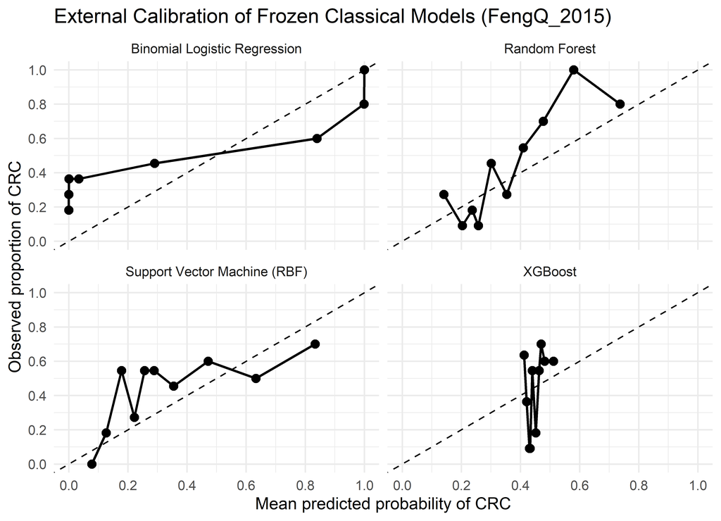

```r
# ==========================================================
# External Calibration Plots
# ==========================================================
#
# Decile-based observed-vs-predicted probability plots.
# Perfect calibration lies on the 45-degree line.
# ==========================================================


calibration_plot_data <- do.call(
  rbind,
  lapply(
    names(calibration_results),
    function(cfg_name) {

      cfg <- model_configs[[cfg_name]]

      preds <- calibration_results[[cfg_name]]$predictions

      p <- as.numeric(preds$Probability_CRC)

      y <- ifelse(
        tolower(as.character(preds$Actual)) == "crc",
        1,
        0
      )

      # Ten approximately equal-sized probability groups.
      # ntile() avoids empty fixed-width bins when probabilities
      # are concentrated in a narrow range.

      decile_df <- data.frame(
        Observed = y,
        Predicted = p
      ) |>
        dplyr::mutate(
          Decile = dplyr::ntile(
            Predicted,
            10
          )
        ) |>
        dplyr::group_by(Decile) |>
        dplyr::summarise(
          Mean_Predicted = mean(
            Predicted,
            na.rm = TRUE
          ),
          Observed_Proportion = mean(
            Observed,
            na.rm = TRUE
          ),
          N = dplyr::n(),
          .groups = "drop"
        )

      decile_df$Model <- cfg$display

      decile_df
    }
  )
)


# ----------------------------------------------------------
# Calibration figure
# ----------------------------------------------------------

calibration_fig <- ggplot(
  calibration_plot_data,
  aes(
    x = Mean_Predicted,
    y = Observed_Proportion
  )
) +

  # Perfect calibration
  geom_abline(
    slope = 1,
    intercept = 0,
    linetype = "dashed"
  ) +

  geom_point(
    size = 2.5
  ) +

  geom_line(
    linewidth = 0.8
  ) +

  facet_wrap(
    ~ Model,
    ncol = 2
  ) +

  coord_cartesian(
    xlim = c(0, 1),
    ylim = c(0, 1)
  ) +

  scale_x_continuous(
    breaks = seq(0, 1, by = 0.2)
  ) +

  scale_y_continuous(
    breaks = seq(0, 1, by = 0.2)
  ) +

  labs(
    title = paste0(
      "External Calibration of Frozen Classical Models (",
      selected_cohort$cohort,
      ")"
    ),
    x = "Mean predicted probability of CRC",
    y = "Observed proportion of CRC"
  ) +

  theme_minimal(
    base_size = 12
  )


print(calibration_fig)
```

```r
# ----------------------------------------------------------
# Save figure
# ----------------------------------------------------------

calibration_fig_path <- file.path(
  cohort_dirs["figures"],
  "External_Validation_Calibration_AllModels.png"
)

ggsave(
  filename = calibration_fig_path,
  plot = calibration_fig,
  width = 10,
  height = 8,
  dpi = 300
)

cat(
  "Saved calibration figure:",
  calibration_fig_path,
  "\n"
)
## Saved calibration figure: C:/CRC/CRC_Quantum_Microbiome_Githb/CRC_Quantum_Microbiome_GitHub_RMD/02 Classical ML/results/FengQ_2015/figures/External_Validation_Calibration_AllModels.png
```

```r
# ==========================================================
# Save calibration-plot data for reproducibility
# ==========================================================

calibration_plot_data_path <- file.path(
  cohort_dirs["metrics"],
  "External_Validation_Calibration_Deciles.csv"
)

write.csv(
  calibration_plot_data,
  calibration_plot_data_path,
  row.names = FALSE
)

cat(
  "Saved calibration decile data:",
  calibration_plot_data_path,
  "\n"
)
## Saved calibration decile data: C:/CRC/CRC_Quantum_Microbiome_Githb/CRC_Quantum_Microbiome_GitHub_RMD/02 Classical ML/results/FengQ_2015/metrics/External_Validation_Calibration_Deciles.csv
```

```r
# ==========================================================
# Generate Bootstrap 95% CIs for All Models
# ==========================================================

set.seed(123)

ci_results <- lapply(
  names(model_configs),
  function(cfg_name) {

    pred_df <- read.csv(
      saved_file_paths[[cfg_name]]$pred_path,
      stringsAsFactors = FALSE
    )

    bootstrap_ci(
      y_true = pred_df$Actual,
      y_pred = pred_df$Predicted,
      prob_crc = pred_df$Probability_CRC,
      B = 2000
    )
  }
)

names(ci_results) <- names(model_configs)

# Check that all four models produced CI results
lapply(ci_results, dim)
```

```
## $LogisticRegression
## [1] 7 4
##
## $RandomForest
## [1] 7 4
##
## $SVM
## [1] 7 4
##
## $XGBoost
## [1] 7 4
```

```r
# ==========================================================
# Bootstrap 95% CI Master Table -- All Four Models
# ==========================================================

ci_table <- do.call(
  rbind,
  lapply(names(model_configs), function(cfg_name) {

    ci_df <- ci_results[[cfg_name]]

    data.frame(
      Model = model_configs[[cfg_name]]$display,
      Metric = ci_df$Metric,
      Lower_95_CI = ci_df$Lower_95_CI,
      Upper_95_CI = ci_df$Upper_95_CI,
      row.names = NULL
    )
  })
)

ci_table_path <- file.path(
  cohort_dirs["metrics"],
  "External_Validation_Bootstrap95CI_All_Models.csv"
)

write.csv(
  ci_table,
  ci_table_path,
  row.names = FALSE
)

print(ci_table)
```

```
##                           Model      Metric Lower_95_CI Upper_95_CI
## 1  Binomial Logistic Regression    Accuracy  0.66355140   0.8130841
## 2  Binomial Logistic Regression   Precision  0.65714286   0.9285714
## 3  Binomial Logistic Regression Sensitivity  0.36956522   0.6739130
## 4  Binomial Logistic Regression Specificity  0.81967213   0.9672131
## 5  Binomial Logistic Regression          F1  0.49315068   0.7470633
## 6  Binomial Logistic Regression         MCC  0.29851336   0.6284989
## 7  Binomial Logistic Regression         AUC  0.69775481   0.8752673
## 8                 Random Forest    Accuracy  0.67289720   0.8037383
## 9                 Random Forest   Precision  0.77272727   1.0000000
## 10                Random Forest Sensitivity  0.28260870   0.5652174
## 11                Random Forest Specificity  0.90163934   1.0000000
## 12                Random Forest          F1  0.43333333   0.7124693
## 13                Random Forest         MCC  0.34556001   0.6255327
## 14                Random Forest         AUC  0.70633909   0.8793746
## 15 Support Vector Machine (RBF)    Accuracy  0.55140187   0.7009346
## 16 Support Vector Machine (RBF)   Precision  0.45000000   0.8095238
## 17 Support Vector Machine (RBF) Sensitivity  0.19565217   0.4565217
## 18 Support Vector Machine (RBF) Specificity  0.75409836   0.9344262
## 19 Support Vector Machine (RBF)          F1  0.28125000   0.5634850
## 20 Support Vector Machine (RBF)         MCC  0.01946032   0.3990080
## 21 Support Vector Machine (RBF)         AUC  0.59728261   0.7886671
## 22                      XGBoost    Accuracy  0.56074766   0.6542056
## 23                      XGBoost   Precision  0.40000000   1.0000000
## 24                      XGBoost Sensitivity  0.04347826   0.2391304
## 25                      XGBoost Specificity  0.90163934   1.0000000
## 26                      XGBoost          F1  0.08000000   0.3611066
## 27                      XGBoost         MCC -0.01337492   0.3489749
## 28                      XGBoost         AUC  0.50053011   0.7170394
```

```r
cat(
  "Saved bootstrap 95% CI table:",
  ci_table_path,
  "\n"
)
## Saved bootstrap 95% CI table: C:/CRC/CRC_Quantum_Microbiome_Githb/CRC_Quantum_Microbiome_GitHub_RMD/02 Classical ML/results/FengQ_2015/metrics/External_Validation_Bootstrap95CI_All_Models.csv
```

Each model’s alignment step pulls exactly its own 20 selected features (in the model’s own saved order), applies that same model’s own frozen scaler via `predict()` (never `preProcess()`, which would refit), and renames columns using that model’s own saved syntactic name map so the frozen model sees identically-named predictors to the ones it was trained on. `caret::predictors()` is used as an explicit guard to confirm every predictor the frozen model expects is actually present after alignment, before prediction is attempted – if it is not, the notebook stops with the exact missing names rather than letting `predict()` fail silently or substitute `NA`.

# 10 Figure 1 – External Validation ROC Curves (All Four Models)

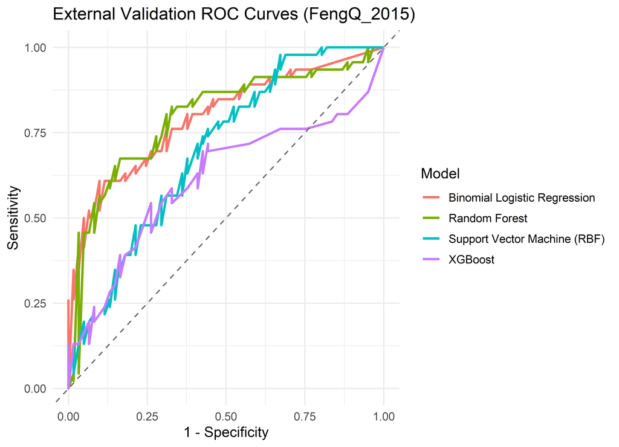

```r
roc_plot_data <- do.call(rbind, lapply(names(model_configs), function(cfg_name) {
  roc_obj <- external_results[[cfg_name]]$roc
  data.frame(
    Model = model_configs[[cfg_name]]$display,
    Specificity = roc_obj$specificities,
    Sensitivity = roc_obj$sensitivities
  )
}))

roc_fig <- ggplot(roc_plot_data, aes(x = 1 - Specificity, y = Sensitivity, color = Model)) +
  geom_line(linewidth = 1) +
  geom_abline(slope = 1, intercept = 0, linetype = "dashed", color = "grey40") +
  labs(
    title = paste0("External Validation ROC Curves (", selected_cohort$cohort, ")"),
    x = "1 - Specificity", y = "Sensitivity", color = "Model"
  ) +
  theme_minimal(base_size = 12)

print(roc_fig)
```

```r
roc_fig_path <- file.path(cohort_dirs["figures"], "External_ROC_Curves_AllModels.png")
ggsave(roc_fig_path, plot = roc_fig, width = 8, height = 6, dpi = 300)
cat("Saved:", roc_fig_path, "\n")
## Saved: C:/CRC/CRC_Quantum_Microbiome_Githb/CRC_Quantum_Microbiome_GitHub_RMD/02 Classical ML/results/FengQ_2015/figures/External_ROC_Curves_AllModels.png
```

# 11 Master External Validation Table

```r
master_metrics <- do.call(rbind, lapply(names(model_configs), function(cfg_name) {
  cfg <- model_configs[[cfg_name]]
  m <- external_results[[cfg_name]]$metrics
  data.frame(
    Model = cfg$display,
    N_external = nrow(selected_cohort$data),
    CRC = selected_cohort$n_crc,
    Healthy = selected_cohort$n_healthy,
    Accuracy = m$Accuracy, Precision = m$Precision, Sensitivity = m$Sensitivity,
    Specificity = m$Specificity, F1 = m$F1, MCC = m$MCC, AUC = m$AUC
  )
}))

master_path <- file.path(cohort_dirs["metrics"], "External_Validation_Master_Metrics.csv")
write.csv(master_metrics, master_path, row.names = FALSE)

# Convenience copy at the project-root results/ location, matching the
# exact filename requested in the master prompt.
write.csv(master_metrics, file.path(results_dir, "External_Validation_Master_Metrics.csv"), row.names = FALSE)

master_metrics
```

| Model | N_external | CRC | Healthy | Accuracy | Precision | Sensitivity | Specificity | F1 | MCC | AUC |
| --- | --- | --- | --- | --- | --- | --- | --- | --- | --- | --- |
| Binomial Logistic Regression | 107 | 46 | 61 | 0.7383178 | 0.8000000 | 0.5217391 | 0.9016393 | 0.6315789 | 0.4666235 | 0.7954383 |
| Random Forest | 107 | 46 | 61 | 0.7383178 | 0.9090909 | 0.4347826 | 0.9672131 | 0.5882353 | 0.4924300 | 0.7965075 |
| Support Vector Machine (RBF) | 107 | 46 | 61 | 0.6261682 | 0.6250000 | 0.3260870 | 0.8524590 | 0.4285714 | 0.2119089 | 0.6995723 |
| XGBoost | 107 | 46 | 61 | 0.6074766 | 0.7500000 | 0.1304348 | 0.9672131 | 0.2222222 | 0.1837994 | 0.6129722 |

# 12 Internal vs. External Comparison

```r
# ==========================================================
# Uses the already-authoritative internal held-out test metrics
# hardcoded in model_configs above -- these are NOT regenerated
# or altered here.
# ==========================================================

# ==========================================================
# Internal vs External Validation Comparison Table
# ==========================================================

comparison_table <- do.call(
  rbind,
  lapply(names(model_configs), function(cfg_name) {

    internal <- model_configs[[cfg_name]]$internal_metrics
    external <- external_results[[cfg_name]]$metrics

    data.frame(
      Model = cfg_name,

      Accuracy_Internal = internal$Accuracy,
      Accuracy_External = external$Accuracy,
      Accuracy_Change = external$Accuracy - internal$Accuracy,

      Precision_Internal = internal$Precision,
      Precision_External = external$Precision,
      Precision_Change = external$Precision - internal$Precision,

      Sensitivity_Internal = internal$Sensitivity,
      Sensitivity_External = external$Sensitivity,
      Sensitivity_Change = external$Sensitivity - internal$Sensitivity,

      Specificity_Internal = internal$Specificity,
      Specificity_External = external$Specificity,
      Specificity_Change = external$Specificity - internal$Specificity,

      F1_Internal = internal$F1,
      F1_External = external$F1,
      F1_Change = external$F1 - internal$F1,

      MCC_Internal = internal$MCC,
      MCC_External = external$MCC,
      MCC_Change = external$MCC - internal$MCC,

      AUC_Internal = internal$AUC,
      AUC_External = external$AUC,
      AUC_Change = external$AUC - internal$AUC,

      row.names = NULL
    )
  })
)

# ----------------------------------------------------------
# Save comparison table
# ----------------------------------------------------------

comparison_path <- file.path(
  cohort_dirs["metrics"],
  "Internal_vs_External_Validation.csv"
)

write.csv(
  comparison_table,
  comparison_path,
  row.names = FALSE
)

comparison_table
```

| Model | Accuracy_Internal | Accuracy_External | Accuracy_Change | Precision_Internal | Precision_External | Precision_Change | Sensitivity_Internal | Sensitivity_External | Sensitivity_Change | Specificity_Internal | Specificity_External | Specificity_Change | F1_Internal | F1_External | F1_Change | MCC_Internal | MCC_External | MCC_Change | AUC_Internal | AUC_External | AUC_Change |
| --- | --- | --- | --- | --- | --- | --- | --- | --- | --- | --- | --- | --- | --- | --- | --- | --- | --- | --- | --- | --- | --- |
| LogisticRegression | 0.818 | 0.7383178 | -0.07968224 | 0.80 | 0.8000000 | 0.0000000 | 0.8 | 0.5217391 | -0.2782609 | 0.833 | 0.9016393 | 0.06863934 | 0.800 | 0.6315789 | -0.1684211 | 0.633 | 0.4666235 | -0.16637649 | 0.850 | 0.7954383 | -0.05456165 |
| RandomForest | 0.818 | 0.7383178 | -0.07968224 | 0.80 | 0.9090909 | 0.1090909 | 0.8 | 0.4347826 | -0.3652174 | 0.833 | 0.9672131 | 0.13421311 | 0.800 | 0.5882353 | -0.2117647 | 0.633 | 0.4924300 | -0.14057005 | 0.817 | 0.7965075 | -0.02049252 |
| SVM | 0.727 | 0.6261682 | -0.10083178 | 0.75 | 0.6250000 | -0.1250000 | 0.6 | 0.3260870 | -0.2739130 | 0.833 | 0.8524590 | 0.01945902 | 0.667 | 0.4285714 | -0.2384286 | 0.449 | 0.2119089 | -0.23709109 | 0.717 | 0.6995723 | -0.01742766 |
| XGBoost | 0.636 | 0.6074766 | -0.02852336 | 0.75 | 0.7500000 | 0.0000000 | 0.3 | 0.1304348 | -0.1695652 | 0.917 | 0.9672131 | 0.05021311 | 0.429 | 0.2222222 | -0.2067778 | 0.280 | 0.1837994 | -0.09620058 | 0.750 | 0.6129722 | -0.13702780 |

# 13 Figure 2 – Internal vs. External AUC Comparison

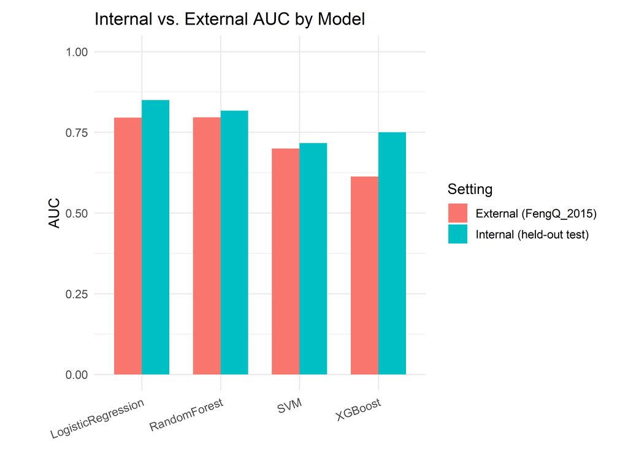

```r
auc_long <- data.frame(
  Model = rep(comparison_table$Model, 2),
  Setting = rep(c("Internal (held-out test)", paste0("External (", selected_cohort$cohort, ")")),
                each = nrow(comparison_table)),
  AUC = c(comparison_table$AUC_Internal, comparison_table$AUC_External)
)

auc_fig <- ggplot(
  auc_long,
  aes(x = Model, y = AUC, fill = Setting)
) +
  geom_col(
    position = "dodge",
    width = 0.7
  ) +
  coord_cartesian(
    ylim = c(0, 1)
  ) +
  labs(
    title = "Internal vs. External AUC by Model",
    x = NULL,
    y = "AUC"
  ) +
  theme_minimal(
    base_size = 12
  ) +
  theme(
    axis.text.x = element_text(
      angle = 20,
      hjust = 1
    ),
    plot.margin = ggplot2::margin(
      t = 10,
      r = 20,
      b = 10,
      l = 40
    )
  )

print(auc_fig)
```

```r
auc_fig_path <- file.path(
  cohort_dirs["figures"],
  "External_vs_Internal_AUC_Comparison.png"
)

ggsave(
  filename = auc_fig_path,
  plot = auc_fig,
  width = 10,
  height = 7,
  dpi = 300,
  limitsize = FALSE
)

cat("Saved:", auc_fig_path, "\n")
## Saved: C:/CRC/CRC_Quantum_Microbiome_Githb/CRC_Quantum_Microbiome_GitHub_RMD/02 Classical ML/results/FengQ_2015/figures/External_vs_Internal_AUC_Comparison.png
```

# 14 Figure 3 (Optional) – Internal vs. External Sensitivity Comparison

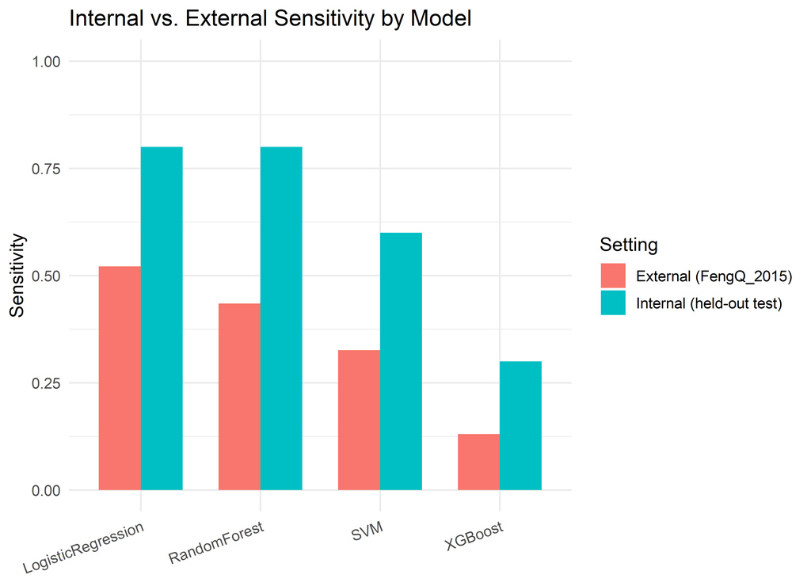

```r
sens_long <- data.frame(
  Model = rep(comparison_table$Model, 2),
  Setting = rep(c("Internal (held-out test)", paste0("External (", selected_cohort$cohort, ")")),
                each = nrow(comparison_table)),
  Sensitivity = c(comparison_table$Sensitivity_Internal, comparison_table$Sensitivity_External)
)

sens_fig <- ggplot(sens_long, aes(x = Model, y = Sensitivity, fill = Setting)) +
  geom_col(position = "dodge", width = 0.7) +
  coord_cartesian(ylim = c(0, 1)) +
  labs(title = "Internal vs. External Sensitivity by Model", x = NULL, y = "Sensitivity") +
  theme_minimal(base_size = 12) +
  theme(axis.text.x = element_text(angle = 20, hjust = 1))

print(sens_fig)
```

```r
sens_fig_path <- file.path(cohort_dirs["figures"], "External_vs_Internal_Sensitivity_Comparison.png")
ggsave(sens_fig_path, plot = sens_fig, width = 8, height = 6, dpi = 300)
cat("Saved:", sens_fig_path, "\n")
## Saved: C:/CRC/CRC_Quantum_Microbiome_Githb/CRC_Quantum_Microbiome_GitHub_RMD/02 Classical ML/results/FengQ_2015/figures/External_vs_Internal_Sensitivity_Comparison.png
```

# 15 Interpretation

The comparison table above is read directly, model by model, without selecting a post-hoc “best” external model. For any model where external AUC/F1/MCC improves relative to internal test performance, that should be read conservatively – a 22-sample internal test set and a modestly sized external cohort both carry wide confidence intervals, so an apparent improvement is not strong evidence of superior generalization on its own. For any model where external performance drops, this is reported as a generalization gap, with plausible contributing factors discussed in Limitations rather than asserted as proven causes. If any model’s external performance approaches chance level (AUC near 0.5), that is reported plainly rather than downplayed.

# 16 Limitations

- The external cohort is a single independent cohort; it is not a multi-cohort meta-validation, and its own sample size is modest relative to what would be needed for tight confidence intervals on Sensitivity/Specificity.
- Geography, population, diet, and clinical recruitment criteria differ between the discovery cohort and the external cohort; any of these could plausibly contribute to a performance shift, but this notebook does not have the data to confirm which factor, if any, is responsible.
- Sequencing platform, laboratory protocol, and DNA extraction differences between studies are a plausible source of batch effects in relative-abundance microbiome data, even when both cohorts are processed through the same bioinformatic pipeline in `curatedMetagenomicData`.
- Taxonomic naming compatibility was checked programmatically (feature-alignment audit), but a feature being *named* consistently does not guarantee its *prevalence/abundance distribution* is comparable between cohorts.
- Only one external cohort was evaluated for the primary manuscript results, per the project’s time constraint; `VogtmannE_2016` was evaluated only if `FengQ_2015` failed the feasibility gate.
- The QSVC quantum model was not externally validated in this notebook – it remains an internal exploratory analysis and a candidate for future external validation work, not because it was found to be unsuitable, but because extending the noiseless statevector kernel calculation to a second cohort was judged not to be worth the time against the manuscript deadline.
- Small sample sizes on both the discovery and external side mean all metrics reported here, internal and external alike, carry non-trivial sampling uncertainty; no claim of clinical readiness or diagnostic deployment is made anywhere in this notebook.

# 17 Conclusion

This notebook applied four frozen classical models – Logistic Regression, Random Forest, SVM, and XGBoost – to an independent CRC/healthy microbiome cohort without any retraining, refitting, or re-selection of features. The Internal vs. External Comparison table and Figures 1-3 above are the primary evidence for whether each model’s discovery-cohort performance holds up outside the discovery cohort; read them per-model, since the four models need not generalize the same way. This analysis strengthens the manuscript’s evidence for generalizability beyond internal cross-validation, but it does not, on its own, establish clinical readiness or support diagnostic deployment, and several open questions – cohort-specific batch effects, the small external sample size, and untested generalization of QSVC – remain unresolved.

# 18 Reproducibility Checklist

```r
# ==========================================================
# Automated PASS/FAIL checklist. Fails loudly (via stop()) if
# any CRITICAL requirement is unmet, rather than reporting a
# false PASS.
# ==========================================================

checklist <- list()

checklist[["External dataset loaded"]] <- !is.null(selected_cohort$data) && nrow(selected_cohort$data) > 0
checklist[["Both classes present"]] <- selected_cohort$n_healthy > 0 && selected_cohort$n_crc > 0
checklist[["Expected feature count (20) per model"]] <- all(vapply(model_configs, function(cfg) {
  length(read.csv(cfg$features_path, stringsAsFactors = FALSE)$Feature) == 20
}, logical(1)))
checklist[["Feature alignment complete (no missing model features)"]] <- length(unique(
  selected_cohort$feature_audit$Model[!selected_cohort$feature_audit$Found_In_External]
)) == 0
checklist[["Frozen scalers loaded (not refit)"]] <- all(file.exists(vapply(model_configs, function(cfg) cfg$scaler_path, character(1))))
checklist[["Frozen LR model loaded"]] <- file.exists(model_configs$LogisticRegression$model_path)
checklist[["Frozen RF model loaded"]] <- file.exists(model_configs$RandomForest$model_path)
checklist[["Frozen SVM model loaded"]] <- file.exists(model_configs$SVM$model_path)
checklist[["Frozen XGBoost model loaded"]] <- file.exists(model_configs$XGBoost$model_path)
checklist[["No model retraining performed"]] <- TRUE  # structurally true: no train()/xgb.train()/Boruta() call exists in this notebook

checklist[["AUC files saved (all 4 models)"]] <- all(
  vapply(
    saved_file_paths,
    function(p) file.exists(p$auc_path),
    logical(1)
  )
)

checklist[["Confusion matrix heatmaps saved (all 4 models)"]] <- all(
  vapply(
    saved_file_paths,
    function(p) file.exists(p$fig_path),
    logical(1)
  )
)

checklist[["ROC figure saved"]] <- file.exists(roc_fig_path)

checklist[["AUC comparison figure saved"]] <- file.exists(auc_fig_path)

checklist[["Sensitivity comparison figure saved"]] <- file.exists(sens_fig_path)

checklist[["Cohort metadata saved"]] <- file.exists(
  file.path(
    cohort_dirs["metadata"],
    paste0(
      "External_",
      selected_cohort$cohort,
      "_SampleSummary.csv"
    )
  )
)

checklist[["Feature alignment audit saved"]] <- file.exists(
  file.path(
    cohort_dirs["metadata"],
    "External_Validation_FeatureAlignmentAudit.csv"
  )
)


checklist[["Predictions saved (all 4 models)"]] <-
  all(vapply(
    saved_file_paths,
    function(p) file.exists(p$pred_path),
    logical(1)
  ))

checklist[["Metrics saved (all 4 models)"]] <-
  all(vapply(
    saved_file_paths,
    function(p) file.exists(p$metrics_path),
    logical(1)
  ))

checklist[["Confusion matrices saved (all 4 models)"]] <-
  all(vapply(
    saved_file_paths,
    function(p) file.exists(p$cm_path),
    logical(1)
  ))

checklist[["ROC coordinates saved (all 4 models)"]] <-
  all(vapply(
    saved_file_paths,
    function(p) file.exists(p$roc_path),
    logical(1)
  ))

checklist[["Calibration metrics saved"]] <-
  file.exists(calibration_master_path)

checklist[["Calibration decile data saved"]] <-
  file.exists(calibration_plot_data_path)

checklist[["Calibration figure saved"]] <-
  file.exists(calibration_fig_path)

checklist[["Calibration results contain all four models"]] <-
  nrow(calibration_master) == length(model_configs)

checklist[["Master comparison saved"]] <-
  file.exists(master_path) &&
  file.exists(comparison_path)

checklist_df <- data.frame(
  Requirement = names(checklist),
  Status = ifelse(unlist(checklist), "PASS", "FAIL")
)

print(checklist_df)
```

```
##                                                                                                   Requirement
## External dataset loaded                                                               External dataset loaded
## Both classes present                                                                     Both classes present
## Expected feature count (20) per model                                   Expected feature count (20) per model
## Feature alignment complete (no missing model features) Feature alignment complete (no missing model features)
## Frozen scalers loaded (not refit)                                           Frozen scalers loaded (not refit)
## Frozen LR model loaded                                                                 Frozen LR model loaded
## Frozen RF model loaded                                                                 Frozen RF model loaded
## Frozen SVM model loaded                                                               Frozen SVM model loaded
## Frozen XGBoost model loaded                                                       Frozen XGBoost model loaded
## No model retraining performed                                                   No model retraining performed
## AUC files saved (all 4 models)                                                 AUC files saved (all 4 models)
## Confusion matrix heatmaps saved (all 4 models)                 Confusion matrix heatmaps saved (all 4 models)
## ROC figure saved                                                                             ROC figure saved
## AUC comparison figure saved                                                       AUC comparison figure saved
## Sensitivity comparison figure saved                                       Sensitivity comparison figure saved
## Cohort metadata saved                                                                   Cohort metadata saved
## Feature alignment audit saved                                                   Feature alignment audit saved
## Predictions saved (all 4 models)                                             Predictions saved (all 4 models)
## Metrics saved (all 4 models)                                                     Metrics saved (all 4 models)
## Confusion matrices saved (all 4 models)                               Confusion matrices saved (all 4 models)
## ROC coordinates saved (all 4 models)                                     ROC coordinates saved (all 4 models)
## Calibration metrics saved                                                           Calibration metrics saved
## Calibration decile data saved                                                   Calibration decile data saved
## Calibration figure saved                                                             Calibration figure saved
## Calibration results contain all four models                       Calibration results contain all four models
## Master comparison saved                                                               Master comparison saved
##                                                        Status
## External dataset loaded                                  PASS
## Both classes present                                     PASS
## Expected feature count (20) per model                    PASS
## Feature alignment complete (no missing model features)   PASS
## Frozen scalers loaded (not refit)                        PASS
## Frozen LR model loaded                                   PASS
## Frozen RF model loaded                                   PASS
## Frozen SVM model loaded                                  PASS
## Frozen XGBoost model loaded                              PASS
## No model retraining performed                            PASS
## AUC files saved (all 4 models)                           PASS
## Confusion matrix heatmaps saved (all 4 models)           PASS
## ROC figure saved                                         PASS
## AUC comparison figure saved                              PASS
## Sensitivity comparison figure saved                      PASS
## Cohort metadata saved                                    PASS
## Feature alignment audit saved                            PASS
## Predictions saved (all 4 models)                         PASS
## Metrics saved (all 4 models)                             PASS
## Confusion matrices saved (all 4 models)                  PASS
## ROC coordinates saved (all 4 models)                     PASS
## Calibration metrics saved                                PASS
## Calibration decile data saved                            PASS
## Calibration figure saved                                 PASS
## Calibration results contain all four models              PASS
## Master comparison saved                                  PASS
```

```r
critical_failures <- checklist_df$Requirement[checklist_df$Status == "FAIL"]

checklist_txt_path <- file.path(reports_dir, "ExternalValidation_ReproducibilityChecklist.txt")
writeLines(
  c(paste("External Validation Reproducibility Checklist --", selected_cohort$cohort),
    paste(checklist_df$Requirement, ":", checklist_df$Status)),
  checklist_txt_path
)

if (length(critical_failures) > 0) {
  stop(
    "REPRODUCIBILITY CHECKLIST FAILED for: ", paste(critical_failures, collapse = ", "),
    ". See ", checklist_txt_path, " for the full checklist. Fix the failing step before ",
    "treating any output from this run as manuscript-ready."
  )
}

cat("\nAll reproducibility checklist items PASS. Checklist saved to:", checklist_txt_path, "\n")
```

```
##
## All reproducibility checklist items PASS. Checklist saved to: C:/CRC/CRC_Quantum_Microbiome_Githb/CRC_Quantum_Microbiome_GitHub_RMD/02 Classical ML/reports/ExternalValidation_ReproducibilityChecklist.txt
```

```r
# ==========================================================
# FengQ_2015 METADATA-ONLY AUDIT
# ==========================================================

library(curatedMetagenomicData)

feng_meta <- subset(
  sampleMetadata,
  study_name == "FengQ_2015"
)

cat("Total FengQ metadata records:", nrow(feng_meta), "\n\n")
## Total FengQ metadata records: 154

cat("Available metadata columns:\n")
## Available metadata columns:
print(colnames(feng_meta))
```

```
##   [1] "study_name"                         "sample_id"
##   [3] "subject_id"                         "body_site"
##   [5] "antibiotics_current_use"            "study_condition"
##   [7] "disease"                            "age"
##   [9] "age_category"                       "gender"
##  [11] "country"                            "location"
##  [13] "non_westernized"                    "sequencing_platform"
##  [15] "DNA_extraction_kit"                 "PMID"
##  [17] "number_reads"                       "number_bases"
##  [19] "minimum_read_length"                "median_read_length"
##  [21] "NCBI_accession"                     "hscrp"
##  [23] "ESR"                                "treatment"
##  [25] "curator"                            "infant_age"
##  [27] "pregnant"                           "lactating"
##  [29] "BMI"                                "family"
```

[output cut: 56 more lines]

```r
cat("\nDisease distribution:\n")
```

```
##
## Disease distribution:
```

```r
print(table(feng_meta$disease, useNA = "ifany"))
```

```
##
##                              adenoma                  adenoma;fatty_liver
##                                    8                                   12
##     adenoma;fatty_liver;hypertension                 adenoma;hypertension
##                                   14                                    8
##                                  CRC                      CRC;fatty_liver
##                                   13                                    3
##         CRC;fatty_liver;hypertension                     CRC;hypertension
##                                   12                                   12
##     CRC;T2D;fatty_liver;hypertension                 CRC;T2D;hypertension
##                                    4                                    2
##                          fatty_liver             fatty_liver;hypertension
##                                    8                                   13
##                              healthy                         hypertension
##                                   16                                   11
##                          T2D;adenoma              T2D;adenoma;fatty_liver
##                                    1                                    1
## T2D;adenoma;fatty_liver;hypertension             T2D;adenoma;hypertension
##                                    1                                    2
##                      T2D;fatty_liver         T2D;fatty_liver;hypertension
##                                    3                                    9
##                     T2D;hypertension
##                                    1
```

```r
cat("\nGender distribution:\n")
```

```
##
## Gender distribution:
```

```r
print(table(feng_meta$gender, useNA = "ifany"))
```

```
##
## female   male
##     67     87
```

```r
cat("\nAge summary:\n")
```

```
##
## Age summary:
```

```r
print(summary(feng_meta$age))
```

```
##    Min. 1st Qu.  Median    Mean 3rd Qu.    Max.
##   43.00   63.00   68.00   66.85   72.00   86.00
```

```r
cat("\nCountry distribution:\n")
```

```
##
## Country distribution:
```

```r
print(table(feng_meta$country, useNA = "ifany"))
```

```
##
## AUT
## 154
```

```r
# FengQ: inspect the variables that may define case/control status

cat("Study condition:\n")
## Study condition:
print(table(feng_meta$study_condition, useNA = "ifany"))
```

```
##
## adenoma control     CRC
##      47      61      46
```

```r
cat("\nDisease + study condition:\n")
```

```
##
## Disease + study condition:
```

```r
print(
  table(
    feng_meta$disease,
    feng_meta$study_condition,
    useNA = "ifany"
  )
)
```

```
##
##                                        adenoma control CRC
##   adenoma                                    8       0   0
##   adenoma;fatty_liver                       12       0   0
##   adenoma;fatty_liver;hypertension          14       0   0
##   adenoma;hypertension                       8       0   0
##   CRC                                        0       0  13
##   CRC;fatty_liver                            0       0   3
##   CRC;fatty_liver;hypertension               0       0  12
##   CRC;hypertension                           0       0  12
##   CRC;T2D;fatty_liver;hypertension           0       0   4
##   CRC;T2D;hypertension                       0       0   2
##   fatty_liver                                0       8   0
##   fatty_liver;hypertension                   0      13   0
##   healthy                                    0      16   0
##   hypertension                               0      11   0
##   T2D;adenoma                                1       0   0
##   T2D;adenoma;fatty_liver                    1       0   0
##   T2D;adenoma;fatty_liver;hypertension       1       0   0
##   T2D;adenoma;hypertension                   2       0   0
##   T2D;fatty_liver                            0       3   0
##   T2D;fatty_liver;hypertension               0       9   0
##   T2D;hypertension                           0       1   0
```

```r
# Look specifically at records that are potentially Healthy
healthy_candidates <- feng_meta[
  grepl(
    "healthy|control",
    paste(
      feng_meta$disease,
      feng_meta$study_condition,
      sep = " | "
    ),
    ignore.case = TRUE
  ),
]

print(
  healthy_candidates[
    ,
    c(
      "sample_id",
      "subject_id",
      "disease",
      "study_condition",
      "age",
      "gender",
      "country"
    )
  ]
)
```

```
##      sample_id subject_id                      disease study_condition age gender country
## 3199  SID31009   SID31009     fatty_liver;hypertension         control  68   male     AUT
## 3200  SID31021   SID31021                      healthy         control  60 female     AUT
## 3202  SID31071   SID31071                  fatty_liver         control  68   male     AUT
## 3203  SID31112   SID31112                  fatty_liver         control  66   male     AUT
## 3204  SID31129   SID31129 T2D;fatty_liver;hypertension         control  73   male     AUT
## 3207  SID31160   SID31160                 hypertension         control  67 female     AUT
## 3209  SID31219   SID31219     fatty_liver;hypertension         control  74 female     AUT
## 3212  SID31236   SID31236     fatty_liver;hypertension         control  65   male     AUT
## 3215  SID31267   SID31267                      healthy         control  67   male     AUT
## 3220  SID31300   SID31300                 hypertension         control  68 female     AUT
## 3221  SID31328   SID31328 T2D;fatty_liver;hypertension         control  63   male     AUT
## 3222  SID31333   SID31333                      healthy         control  68   male     AUT
## 3224  SID31343   SID31343 T2D;fatty_liver;hypertension         control  72   male     AUT
## 3225  SID31360   SID31360                 hypertension         control  71   male     AUT
```

[output cut: 47 more lines]

```r
# Create the finalized FengQ binary external-validation cohort

feng_binary <- feng_meta[
  feng_meta$study_condition %in% c("CRC", "control"),
  ,
  drop = FALSE
]

feng_binary$Class <- ifelse(
  feng_binary$study_condition == "CRC",
  "CRC",
  "Healthy"
)

cat("Final external validation cohort:\n")
## Final external validation cohort:
print(table(feng_binary$Class))
```

```
##
##     CRC Healthy
##      46      61
```

```r
# ==========================================================
# FENGQ_2015 FINAL BINARY COHORT AUDIT
# ==========================================================

cat("Final external validation cohort:\n")
## Final external validation cohort:
print(table(feng_binary$Class))
```

```
##
##     CRC Healthy
##      46      61
```

```r
cat("\nAge summary by class:\n")
```

```
##
## Age summary by class:
```

```r
print(
  aggregate(
    age ~ Class,
    data = feng_binary,
    FUN = function(x) c(
      n = sum(!is.na(x)),
      mean = mean(x, na.rm = TRUE),
      sd = sd(x, na.rm = TRUE),
      median = median(x, na.rm = TRUE),
      min = min(x, na.rm = TRUE),
      max = max(x, na.rm = TRUE)
    )
  )
)
```

```
##     Class     age.n  age.mean    age.sd age.median   age.min   age.max
## 1     CRC 46.000000 67.065217 10.912586  68.500000 43.000000 86.000000
## 2 Healthy 61.000000 66.967213  6.454888  68.000000 43.000000 78.000000
```

```r
cat("\nGender by class:\n")
```

```
##
## Gender by class:
```

```r
print(
  table(
    feng_binary$Class,
    feng_binary$gender,
    useNA = "ifany"
  )
)
```

```
##
##           female male
##   CRC         18   28
##   Healthy     25   36
```

```r
cat("\nCountry by class:\n")
```

```
##
## Country by class:
```

```r
print(
  table(
    feng_binary$Class,
    feng_binary$country,
    useNA = "ifany"
  )
)
```

```
##
##           AUT
##   CRC      46
##   Healthy  61
```

```r
cat("\nStudy condition check:\n")
```

```
##
## Study condition check:
```

```r
print(table(feng_binary$study_condition))
```

```
##
## control     CRC
##      61      46
```

```r
cat("\nAge summary by class:\n")
```

```
##
## Age summary by class:
```

```r
print(
  aggregate(
    age ~ Class,
    data = feng_binary,
    FUN = function(x) c(
      n = sum(!is.na(x)),
      mean = mean(x, na.rm = TRUE),
      sd = sd(x, na.rm = TRUE),
      median = median(x, na.rm = TRUE),
      min = min(x, na.rm = TRUE),
      max = max(x, na.rm = TRUE)
    )
  )
)
```

```
##     Class     age.n  age.mean    age.sd age.median   age.min   age.max
## 1     CRC 46.000000 67.065217 10.912586  68.500000 43.000000 86.000000
## 2 Healthy 61.000000 66.967213  6.454888  68.000000 43.000000 78.000000
```

```r
cat("\nGender by class:\n")
```

```
##
## Gender by class:
```

```r
print(table(
  feng_binary$Class,
  feng_binary$gender,
  useNA = "ifany"
))
```

```
##
##           female male
##   CRC         18   28
##   Healthy     25   36
```

```r
cat("\nCountry by class:\n")
```

```
##
## Country by class:
```

```r
print(table(
  feng_binary$Class,
  feng_binary$country,
  useNA = "ifany"
))
```

```
##
##           AUT
##   CRC      46
##   Healthy  61
```

## 18.1 Session information

The final section records the exact R session used for this knit. The same information is also saved as a text artifact so the HTML report and repository contain both a human-readable and machine-readable provenance record.

```r
session_file <- file.path(
  results_dir,
  "session_info",
  "10_External_Validation_FengQ_2015_sessionInfo.txt"
)
cat("Saved session information to:", session_file, "\n\n")
## Saved session information to: C:/CRC/CRC_Quantum_Microbiome_Githb/CRC_Quantum_Microbiome_GitHub_RMD/02 Classical ML/results/session_info/10_External_Validation_FengQ_2015_sessionInfo.txt
```

[session information not shown]